# SATSA Data Analysis

Jamie Knight

November 26, 2015

In our data analysis we are looking at how smell changes over time in individuals within the SATSA data.As you will have seen from the data preparation file we have discovered a coding issue that will prevent us from proceeding with our desired analysis and instead we will look for visual confirmation of the coding issue in the data set.

This current longituinal analysis is the beginning of my thesis research where I will examine whether we can predict neurodegenerative diseases with a decline in the sense of smell.

In this data analysis we explore how smell changes over time for the individuals in our sample, using empirical growth plots. We would normally expect to see a decline in smell over time. However, with the coding issue I would expect to see some kind of quadratic relationship over time surrounding the 2 and 3 (Pretty Good and Not So Good) smell variable.

## Load Packages

This section prepares the RStudio environment for all tasks to follow.

If the packages are not insalled:  
(1) Uncomment the install.packages list by highlighting them and holding down Shift CTRL C  
(2) Run the code  
(3) Comment out the insall.packages list using the same process as #1.  
(4) Load the packages.

Installing packages will only need to be done once.  
Loading packages will need to be done at the beginning of each session.

```r
# Load the necessary packages.
base::require(base)
base::require(knitr)
base::require(markdown)
base::require(testit)
base::require(dplyr)
base::require(reshape2)
base::require(stringr)
base::require(stats)
base::require(ggplot2)
base::require(extrafont)
base::require(lattice)
```

If you haven’t done so already, you will need to run the data preparation files which can be found in the data preparation folder. Running the data preparation will give you a long format subset of the data that we are going to work with.

```r
# Link to the data source
pathDir <- getwd()
load(file.path(pathDir,"data/derived/dsLong.rda"))
```

## Subset Data

Here we will generate a small random number of individuals. Our goal is to look at how smell is changing over time in individuals. I would normally expect a liner decline over time however we should see some interesting patterns that reflect the coding issues we have encountered.

```r
####Subset a random sample of participants including all Variables and waves####
#first omit any missing data
satsasm <- na.omit(satsafull)
#the generate a random sample
idx2 <- sample(unique(satsasm$TWINNR), 15)
idfsample2 <- satsasm[satsasm$TWINNR %in% idx2, ]
attach(idfsample2)
save(idfsample2,file="./data/derived/idfsample2.rda")

#if we want to sample individual people we can use this code
#id234 <- satsafull[satsafull$TWINNR==234, ]
```

## Empirical Growth Plots

Now we will look at some longitudinal exploration. Empirical growth plots are a simple way of examining how a person changes over time. In this case Waves are our time variable and we examine how smell changes over time in a small subset of our SATSA data. This will show us who is increasing and who is decreasing over time.

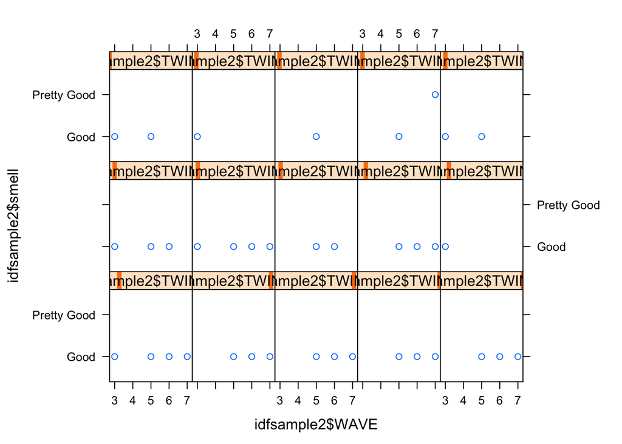

```r
#### Empirical growth plots ####
#plots of MMSE and smell
#use the id sampling dataset to run plots so you dont't crash your computer
xyplot(idfsample2$smell ~ idfsample2$WAVE | idfsample2$TWINNR, data=idfsample2, as.table=T)
```

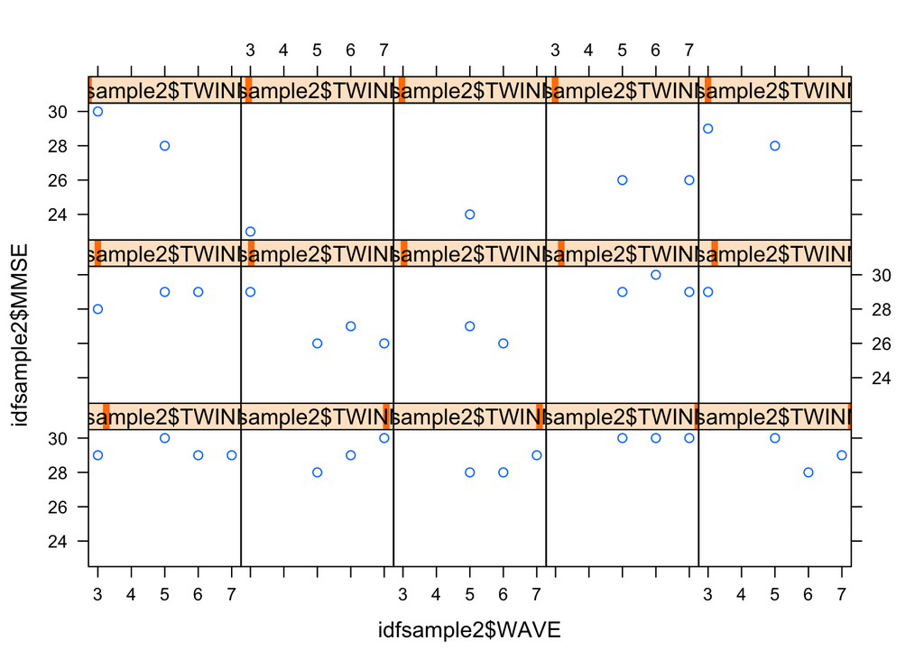

```r
xyplot(idfsample2$MMSE ~ idfsample2$WAVE | idfsample2$TWINNR, data=idfsample2, as.table=T)
```

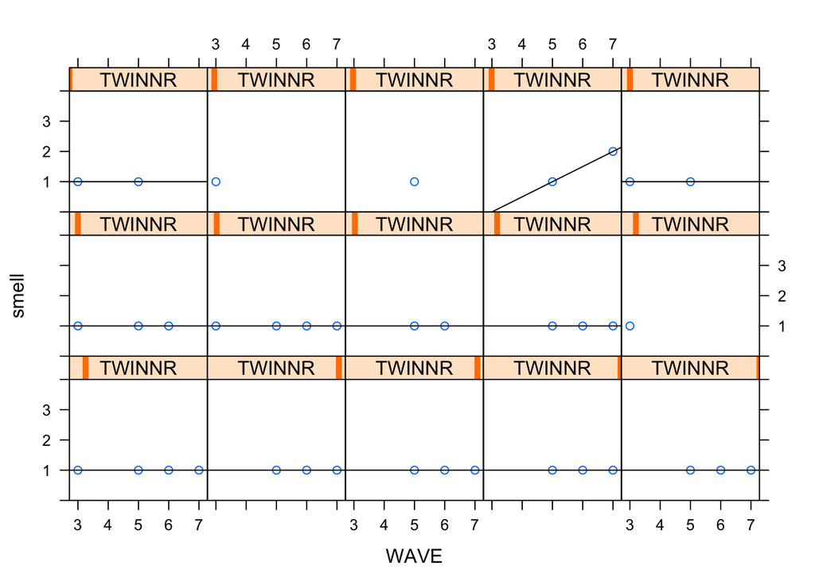

```r
#### Fitted OLS trajectories superimposed on the empirical growth plots.####

#We can look at the full data set if there are not too many subjects, but it may crash your computer...
# xyplot(smell ~ WAVE | TWINNR, data=satsafull,
#        panel = function(x, y){
#          panel.xyplot(x, y)
#          panel.lmline(x, y)
#        }, ylim=c(0, 4), as.table=T)

#examine a smaller subet of the data
#can we facet wrap xyplots? this would give id variable
xyplot(smell ~ WAVE | TWINNR, data=idfsample2,
       panel = function(x, y){
         panel.xyplot(x, y)
         panel.lmline(x, y)
       }, ylim=c(0, 4), as.table=T)
```

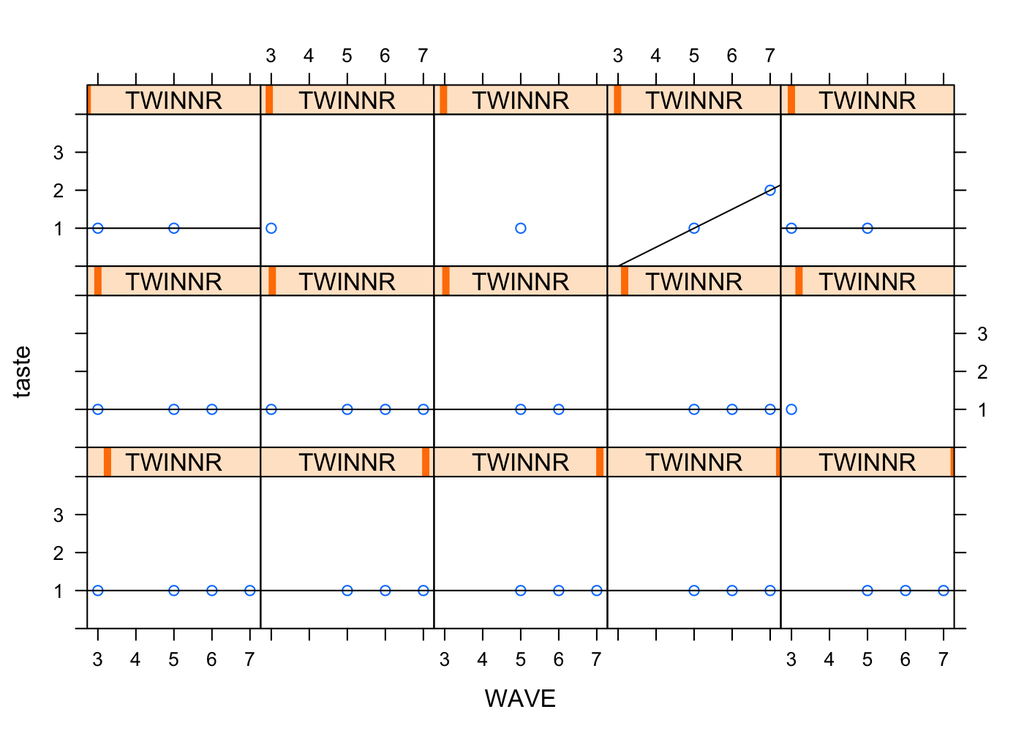

```r
xyplot(taste ~ WAVE | TWINNR, data=idfsample2,
       panel = function(x, y){
         panel.xyplot(x, y)
         panel.lmline(x, y)
       }, ylim=c(0,4), as.table=T)
```

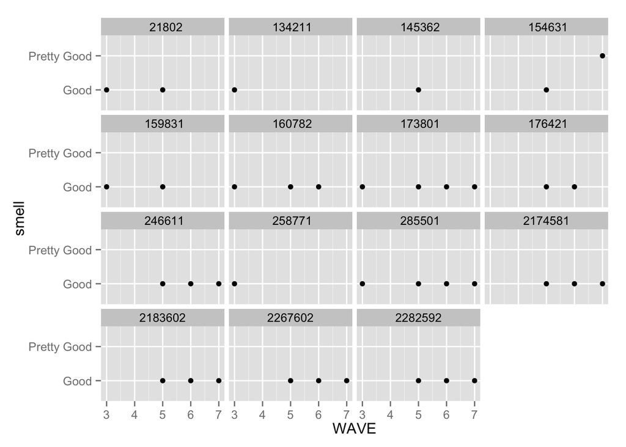

```r
#we can see that smell and taste are reported nearly identically in each individual.

#here we can get the id number for each person in the smaller sample set
p <- ggplot(idfsample2)
p <- p + geom_point(aes(x=WAVE, y=smell))
p <- p + facet_wrap(~TWINNR)
print(p)
```

```r
# Fitting separate within person OLS regression models by id
#error - factors are not allowed
#by(idfsample2, idfsample2$TWINNR, function(x) summary(lm(idfsample2$smell ~ idfsample2$WAVE, data=x)))
```

## By ID

Identify and look at one individual’s change over time

```r
#this is not picking up all the waves for the id number
#factors not allowed in model - Andrey: how to get around this?
id1 <- satsafull[satsafull$TWINNR==112212, ]
id1$model <-  predict(lm(smell~WAVE,id1))
```

## Future Analysis

I am currently waiting to recieve the disease diagnoses data for the SATSA data. This additional variable will be my outcome variable and will include dementia. I will use this to see whether decline in smell over time can predict dementia. Once we resolve the coding issue with how smell is coded over different waves we can proceed with analysis of the data.

## Clean Up

Clean up the global environment and the console.

```r
# # remove all but specified dataset
#rm(list=(ls()[ls()!="satsafull"]))

#remove everything from the environment
base::rm(list=base::ls(all=TRUE))


####THE END####

####Future Analysis####
#look at whether smell can predict dementia
#code dementia to binomial group: yes dementia or no dementia.
#random effect that takes into account baseline smell
#lmer(dementia ~ WAVE*smell + sex + (WAVE|subject), data=satsafull) #lme4
#lme(smell ~ WAVE*dementia + sex + (WAVE|subject), data=satsafull) #lme4
```